# 04_BPhylogenetic_Tree

Roger Calvas

2025-04-10

#Goals We want to investigate and root our tree

# Input

1. raw_preprocessed_physeq.RData
2. ASVs_unrooted.tree
3. MAFFT_aligned_ASVs.fasta

#Before you start

##set my seed

```r
set.seed(39809473)
```

#Load packages

```r
pacman::p_load(tidyverse, phyloseq, ggtree, phytools, tidytree,
               install = FALSE)
```

#Load data files

```r
# Preprocessed phyloseq object
load("data/03_PreProcessing/raw_preprocessed_physeq.RData")
raw_preprocessed_physeq <-
  noControlsMock_ChlorosMitos_physeq
#raw_preprocessed_physeq
# Load in the tree!
unrooted_tree <- read.tree("data/04_Phylogenetic_Tree/ASVs_unrooted.tree")
unrooted_tree
```

```
##
## Phylogenetic tree with 1980 tips and 1978 internal nodes.
##
## Tip labels:
##   ASV_0914, ASV_0997, ASV_0758, ASV_1606, ASV_1768, ASV_1871, ...
## Node labels:
##   , 0.000, 0.888, 0.850, 0.000, 0.924, ...
##
## Unrooted; includes branch length(s).
```

```r
str(unrooted_tree)
```

```
## List of 5
##  $ edge       : int [1:3957, 1:2] 1981 1982 1983 1984 1984 1985 1986 1986 1987 1987 ...
##  $ edge.length: num [1:3957] 0.00053 0.01317 0.00975 0.01983 0.00054 ...
##  $ Nnode      : int 1978
##  $ node.label : chr [1:1978] "" "0.000" "0.888" "0.850" ...
##  $ tip.label  : chr [1:1980] "ASV_0914" "ASV_0997" "ASV_0758" "ASV_1606" ...
##  - attr(*, "class")= chr "phylo"
##  - attr(*, "order")= chr "cladewise"
```

#Merge Phyloseq Object

```r
# Intuition check
stopifnot(ntaxa(raw_preprocessed_physeq) == ntaxa(unrooted_tree))

# Merge the tree with the phyloseq object
unrooted_physeq <-
  merge_phyloseq(raw_preprocessed_physeq, unrooted_tree)
```

[output not shown]

```
## Also defined by 'tidytree'
```

[output not shown]

```
## Also defined by 'tidytree'
```

[output not shown]

```
## Also defined by 'tidytree'
```

[output not shown]

```
## Also defined by 'tidytree'
```

[output not shown]

```
## Also defined by 'tidytree'
```

[output not shown]

```
## Also defined by 'tidytree'
```

[output not shown]

```
## Also defined by 'tidytree'
```

```r
unrooted_physeq
```

```
## phyloseq-class experiment-level object
## otu_table()   OTU Table:         [ 1980 taxa and 161 samples ]
## sample_data() Sample Data:       [ 161 samples by 54 sample variables ]
## tax_table()   Taxonomy Table:    [ 1980 taxa by 9 taxonomic ranks ]
## phy_tree()    Phylogenetic Tree: [ 1980 tips and 1978 internal nodes ]
```

#Plot tree with ‘ggtree’

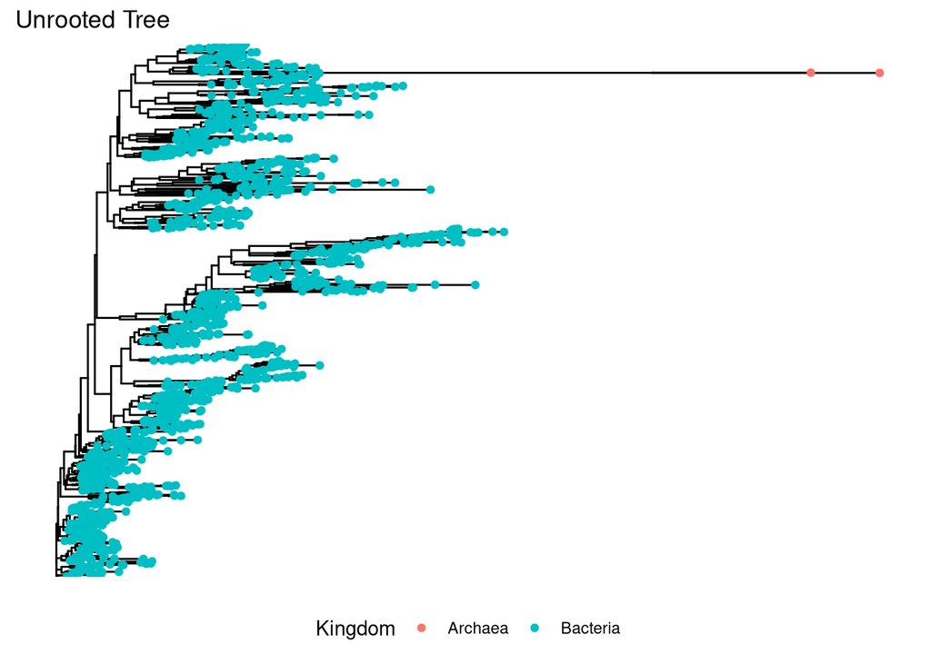

```r
# Make a basic tree
kingdom_tree <-
  ggtree(unrooted_physeq) +
  # color tips by kingdom
  geom_tippoint(mapping = aes(color = Kingdom)) +
#  scale_color_manual(values = c("goldenrod1", "cornflowerblue", "grey")) +
  # Add title
  labs(title = "Unrooted Tree") +
  #move the legend to the bottom
  theme(legend.position = "bottom");

kingdom_tree
```

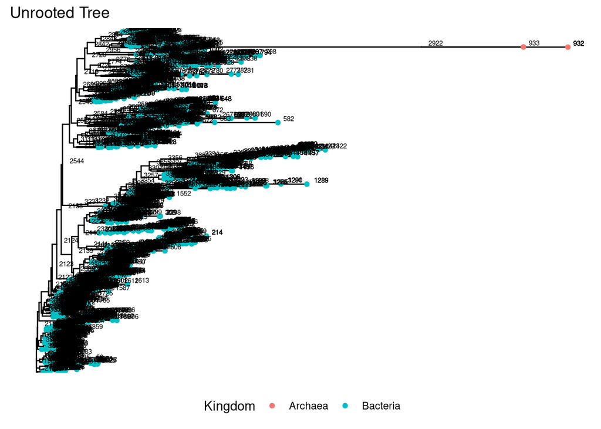

```r
kingdom_node_tree <-
  kingdom_tree +
  # Add the node label
  geom_text(aes(label=node), hjust= -0.5, vjust = -0.3, size = 2)

kingdom_node_tree
```

Branch 1289 and branch 582 look suspiciously lengthy, but branch 1289 has many close ancestors while 582 is not as long so I would say that apart from that is relatively clean, the only other long clade is the archeal.